# Analysis of Leading Causes of Death in the United States, 1999-2016

Christopher Brown (christopherabrown42@gmail.com)

# Disclaimer/version

This report is intended to be a demonstration of of various coding techniques and an exploration of this dataset, and is not intended for publication.

Areas for improvement: The analysis of mean age-adjusted death rate is not particularly valid in current form.

Resolutions: incorporate population data for states, and acquire or compute the weightings used to derive age-adjusted death rates

Last edited on 11/6/18, Reason: further code comments for more complex code chunks

# Preparation of the data

## Load necessary packages

```r
library(tidyverse)    # tidyverse packages include dyplr for data manipulation, and ggplot
library(stringr)      # stringr includes functions for manipulating character strings
library(forcats)      # forcats includes functions for handling factor/categorical variables
library(corrplot)     # this package allows for a correlation plot
```

As a first step, let’s acquire the dataset from [data.gov](https://data.cdc.gov/api/views/bi63-dtpu/rows.csv?accessType=DOWNLOAD&bom=true&format=true) and examine its structure.

```r
# Dataset is loaded with read_csv from the readr package (included with tidyverse)
# Read_csv has better handling of several issues than does read.csv from base R
lcod_us <- read_csv("https://data.cdc.gov/api/views/bi63-dtpu/rows.csv?accessType=DOWNLOAD&bom=true&format=true")

# Glimpse (dplyr) allows for an easily readible snapshot of the structure of the dataset and its initial values
glimpse(lcod_us)
```

```
## Observations: 10,296
## Variables: 6
## $ Year                      <int> 2016, 2016, 2016, 2016, 2016, 2016, ...
## $ `113 Cause Name`          <chr> "Accidents (unintentional injuries) ...
## $ `Cause Name`              <chr> "Unintentional injuries", "Unintenti...
## $ State                     <chr> "Alabama", "Alaska", "Arizona", "Ark...
## $ Deaths                    <dbl> 2755, 439, 4010, 1604, 13213, 2880, ...
## $ `Age-adjusted Death Rate` <dbl> 55.5, 63.1, 54.2, 51.8, 32.0, 51.2, ...
```

## Adjusting variable names

The following code makes adjustments to variable names to follow best practice naming conventions in R.

```r
# Clean up white space in variable names to avoid unexpected errors, and make lower case for consistency
# First, str_replace_all (stringr) replaces spaces with underscores
# Secondly, str_to_lower (stringr) converts all characters to lowercase
names(lcod_us) <- str_to_lower(str_replace_all(names(lcod_us), " ", "_"))

# Additionally, replace the hyphen in Age-adjusted_Death_Rate with an underscore to match R naming conventions
# the hyphen is interpretted as subtraction unless the name of the var is enclosed in backticks ` `
# Lastly, drop the variable 113_Cause_Name because it captures the same effective information as cause_name
# both of these operations are accomplished within a single call from the select function (dplyr)
lcod_us_clean <- lcod_us %>%
  select(everything(), age_adjusted_death_rate = `age-adjusted_death_rate`, -`113_cause_name`)
```

## Factor variables

Next, we’ll change the character type variables into factors, which will be useful for creating plots later on.

```r
# Make state and causes, which are of type character, into variables of type factor using mutate_if (dplyr)
lcod_us_clean <- lcod_us_clean %>%
    mutate_if(is.character, as.factor)
```

# Exploratory Data Analysis

To get a better understanding of the underlying data, let’s view its structure and a summary of the data.

```r
# Use glimpse() and view summary() of data to see how it looks after cleaning
glimpse(lcod_us_clean)
```

```
## Observations: 10,296
## Variables: 5
## $ year                    <int> 2016, 2016, 2016, 2016, 2016, 2016, 20...
## $ cause_name              <fctr> Unintentional injuries, Unintentional...
## $ state                   <fctr> Alabama, Alaska, Arizona, Arkansas, C...
## $ deaths                  <dbl> 2755, 439, 4010, 1604, 13213, 2880, 19...
## $ age_adjusted_death_rate <dbl> 55.5, 63.1, 54.2, 51.8, 32.0, 51.2, 50...
```

```r
summary(lcod_us_clean)
```

```
##       year                    cause_name          state
##  Min.   :1999   All causes         : 936   Alabama   : 198
##  1st Qu.:2003   Alzheimer's disease: 936   Alaska    : 198
##  Median :2008   Cancer             : 936   Arizona   : 198
##  Mean   :2008   CLRD               : 936   Arkansas  : 198
##  3rd Qu.:2012   Diabetes           : 936   California: 198
##  Max.   :2016   Heart disease      : 936   Colorado  : 198
##                 (Other)            :4680   (Other)   :9108
##      deaths        age_adjusted_death_rate
##  Min.   :     21   Min.   :   2.6
##  1st Qu.:    606   1st Qu.:  19.2
##  Median :   1704   Median :  35.8
##  Mean   :  15327   Mean   : 128.0
##  3rd Qu.:   5678   3rd Qu.: 153.0
##  Max.   :2712630   Max.   :1087.3
##
```

At this point, the dataset consists of 5 variables, and 10,296 observations from 1999 to 2016. It contains information from 50 states, the District of Columbia, as well as the United States as a whole. The cause_name variable contains 11 different causes of death, although one of those is *All causes*.

## US census Regions

Next, let’s create a region variable for grouping of states. These groupings will be created from Census Bureau-designated [regions](https://en.wikipedia.org/wiki/List_of_regions_of_the_United_States).

```r
# Region variable: created from Census Bureau-designated regions

# Create character string northeast, comprised of the names of states from the northeast region
northeast <- "Connecticut, Maine, Massachusetts, New Hampshire, Rhode Island, Vermont, New Jersey, New York, Pennsylvania"
# Split northeast into a vector of states
northeast <- unlist(str_split(northeast, ", "))

# Create character string midwst, comprised of the names of states from the midwest region
# named midwst to avoid potential conflict with ggplot2 object: midwest
midwst <- "Illinois, Indiana, Michigan, Ohio, Wisconsin, Iowa, Kansas, Minnesota, Missouri, Nebraska, North Dakota, South Dakota"
# Split midwst into a vector of states
midwst <- unlist(str_split(midwst, ", "))

# Create character string south, comprised of the names of states from the south region
south <- "Delaware, Florida, Georgia, Maryland, North Carolina, South Carolina, Virginia, District of Columbia, West Virginia, Alabama, Kentucky, Mississippi, Tennessee, Arkansas, Louisiana, Oklahoma, Texas"
# Split south into a vector of states
south <- unlist(str_split(south, ", "))

# Create character string west, comprised of the names of states from the west region
west <- "Arizona, Colorado, Idaho, Montana, Nevada, New Mexico, Utah, Wyoming, Alaska, California, Hawaii, Oregon, Washington"
# Split west into a vector of states
west <- unlist(str_split(west, ", "))

# Create Region variable using mutate
# Assign to specified region when a state is in the region vector of the same name
lcod_reg <- lcod_us_clean %>%
  mutate(region = as.factor(case_when(as.character(state) %in% northeast ~ "Northeast",
                            as.character(state) %in% midwst ~ "Midwest",
                            as.character(state) %in% south ~ "South",
                            as.character(state) %in% west ~ "West",
                            TRUE ~ as.character(state)))   # creates "United States" region for all other cases
  )
```

### Leading causes of death

The code below calculates summaries of deaths by combinations of region and cause. This is somewhat skewed, due to the fact that more people live in the *South* census region. However, it is also clear that certain causes of death trend similarly across regions. It isn’t a surprise to see that *heart disease* and *cancer* are the two leading causes of deaths in the United States.

```r
# Top 20 sums of deaths by region and cause
lcod_reg %>%
  # Filter out rows that include All causes of death, or rows that include the United States at large
  filter(cause_name != "All causes",
       region != "United States") %>%
  # Group the data by a combination of region and cause of death
  group_by(region, cause_name) %>%
  # Summarize the deaths based on the grouping above
  summarize(sum_deaths = sum(deaths)) %>%
  # Sort the resulting summary data in descending order
  arrange(desc(sum_deaths)) %>%
  # Display the top 20 results
  head(20)
```

```
## # A tibble: 20 x 3
## # Groups: region [4]
##    region    cause_name             sum_deaths
##    <fctr>    <fctr>                      <dbl>
##  1 South     Heart disease             4316616
##  2 South     Cancer                    3835679
##  3 Midwest   Heart disease             2707321
##  4 Northeast Heart disease             2426139
##  5 Midwest   Cancer                    2411533
##  6 West      Heart disease             2125107
##  7 Northeast Cancer                    2010601
##  8 West      Cancer                    1986723
##  9 South     Stroke                     997268
## 10 South     CLRD                       935532
## 11 South     Unintentional injuries     888670
## 12 Midwest   Stroke                     618471
## 13 Midwest   CLRD                       593684
## 14 West      Stroke                     529274
## 15 South     Diabetes                   509896
## 16 South     Alzheimer's disease        505847
## 17 West      CLRD                       499795
## 18 Midwest   Unintentional injuries     488359
## 19 West      Unintentional injuries     460577
## 20 Northeast Stroke                     435127
```

#### Less likely causes

As it turns out, the least likely causes (recorded in this dataset) tend to be *suicide* and *kidney disease*.

```r
# Bottom 20 sums of deaths by region and cause
lcod_reg %>%
  # Filter out rows that include All causes of death, or rows that include the United States at large
  filter(cause_name != "All causes",
       region != "United States") %>%
  # Group the data by a combination of region and cause of death
  group_by(region, cause_name) %>%
  # Summarize the deaths based on the grouping above
  summarize(sum_deaths = sum(deaths)) %>%
  # Sort the resulting summary data in ascending order
  arrange(sum_deaths) %>%
  # Display the top (effectively bottom due to sorting) 20 results
  head(20)
```

```
## # A tibble: 20 x 3
## # Groups: region [4]
##    region    cause_name              sum_deaths
##    <fctr>    <fctr>                       <dbl>
##  1 Northeast Suicide                      89979
##  2 West      Kidney disease              104764
##  3 Midwest   Suicide                     141069
##  4 West      Suicide                     166107
##  5 Northeast Kidney disease              167116
##  6 Northeast Alzheimer's disease         199866
##  7 Midwest   Kidney disease              205232
##  8 West      Influenza and pneumonia     213677
##  9 Northeast Influenza and pneumonia     223878
## 10 Northeast Diabetes                    230177
## 11 Midwest   Influenza and pneumonia     238741
## 12 South     Suicide                     252688
## 13 West      Diabetes                    265603
## 14 Midwest   Diabetes                    310703
## 15 South     Kidney disease              330868
## 16 Midwest   Alzheimer's disease         333270
## 17 West      Alzheimer's disease         334429
## 18 Northeast Unintentional injuries      340278
## 19 South     Influenza and pneumonia     362673
## 20 Northeast CLRD                        405715
```

The following code creates plots of 50 states and DC’s deaths over time. We’ll investigate the most populous states further.

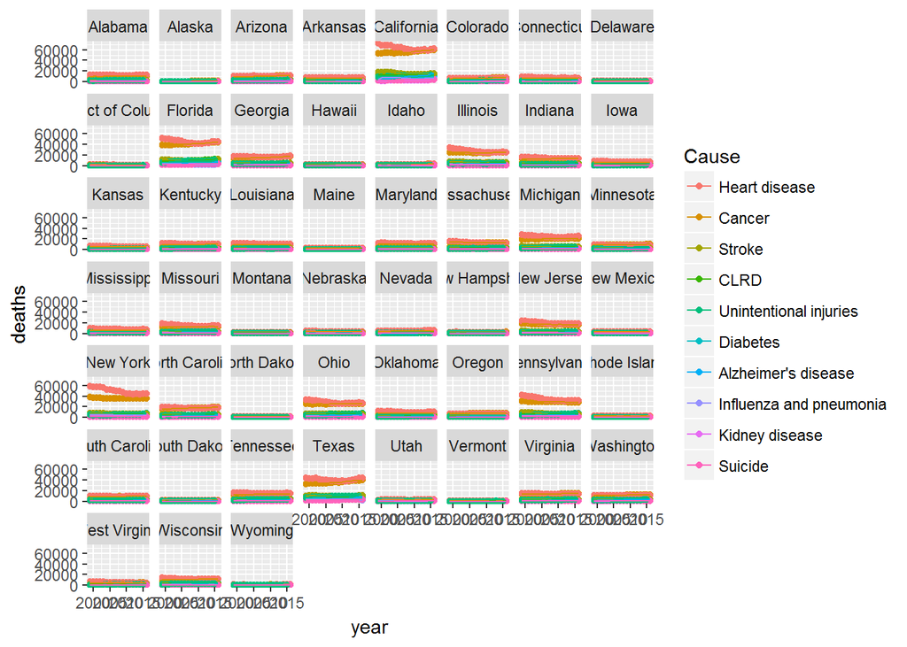

```r
# Filter out rows that include All causes of death, or rows that include the United States at large
filter(lcod_reg, state != "United States", cause_name != 'All causes') %>%
# Create ggplot and aesthetic mappings, including reordering and sorting causes by the amount of deaths
  ggplot(aes(x = year, y = deaths, color = fct_rev(fct_reorder(cause_name, deaths)))) +
  # Add scatterpoint and line layers to the plot
    geom_point() +
    geom_line() +
  # Add faceting by state, which creates a separate plot for each state
    facet_wrap(~ state) +
  # Assign causes to color label legend
    scale_color_discrete(name = "Cause")
```

## Comparison of deaths over time for most populous states

Creating a function to automate plotting for causes of death over time.

```r
# Function for plotting deaths over time according to input state: st
plot_state_deaths <- function(st) {
  lcod_reg %>%
    # Select only the state that was supplied to the function
    filter(state == st) %>%
    # Create ggplot, aesthetic mappings
   ggplot(aes(x = year, y = deaths, color = cause_name)) +
    # Add scatterplot, line, and linear model layers to the plot
    geom_point() +
    geom_line() +
    geom_smooth(method = "lm", se = FALSE) +
    # Add a title to the plot, based on the name of the state
    labs(title =  paste("Deaths for", st, "over time, colored by Cause"))
}
```

### Top 5 states with most deaths

```r
# Filter for the 5 states with the most deaths
top_states_deaths <- lcod_reg %>%
  # Remove United States at large
  filter(state != "United States") %>%
  # Group observations by state
  group_by(state) %>%
  # Summarize the data by creating a sum of deaths
  summarize(num = sum(deaths)) %>%
  # Select 5 states with highest sums of deaths
  top_n(5, num) %>%
  # Sort in descending order
  arrange(desc(num)) %>%
  # Retrieve the vector of 5 states
  pull(state)
```

Now, we’ll call the function we created with the map() funtion from the purrr library. This will call the plot function once for each of the top 5 states with the most deaths.

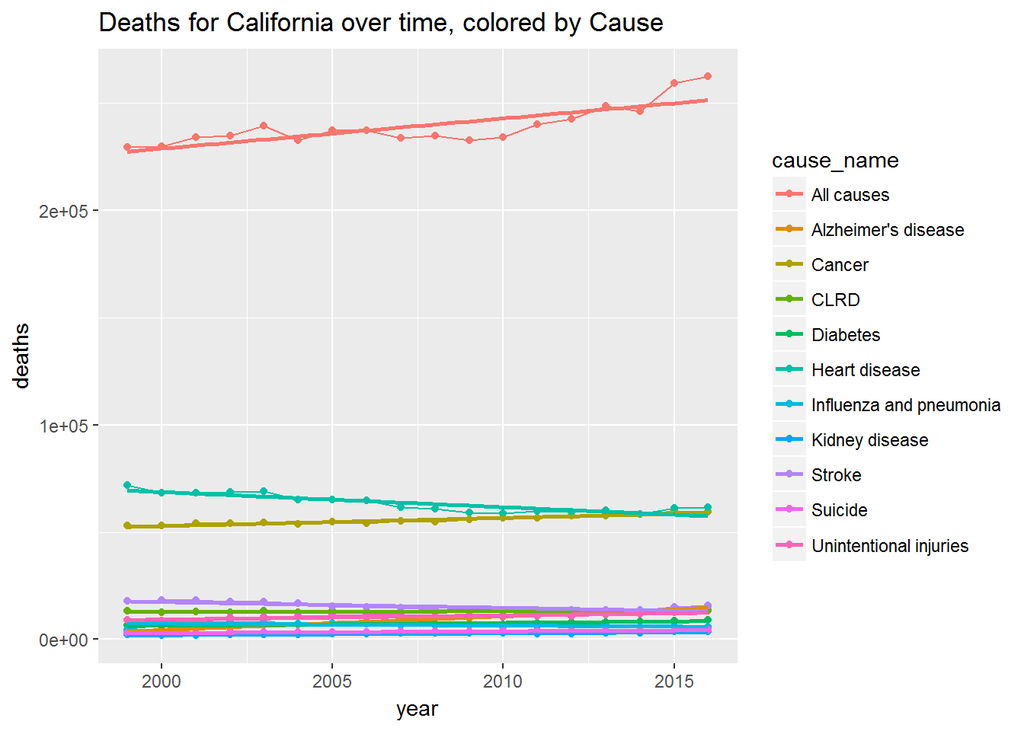

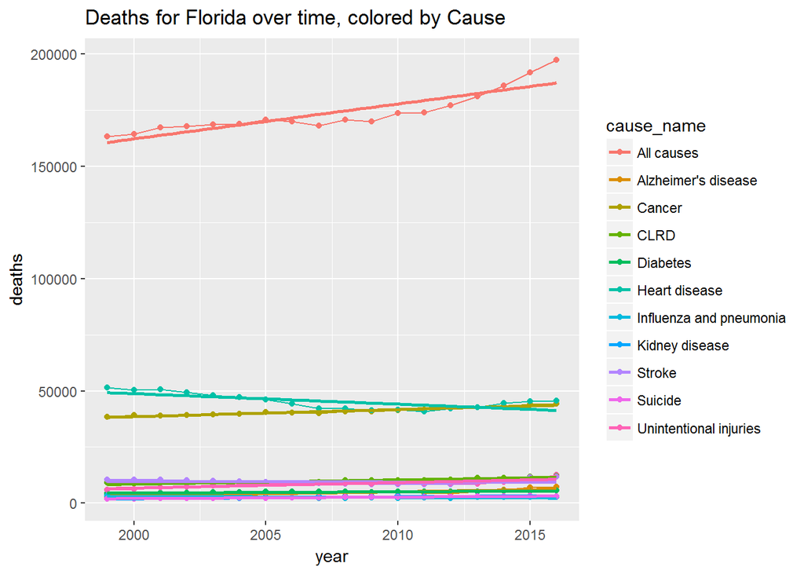

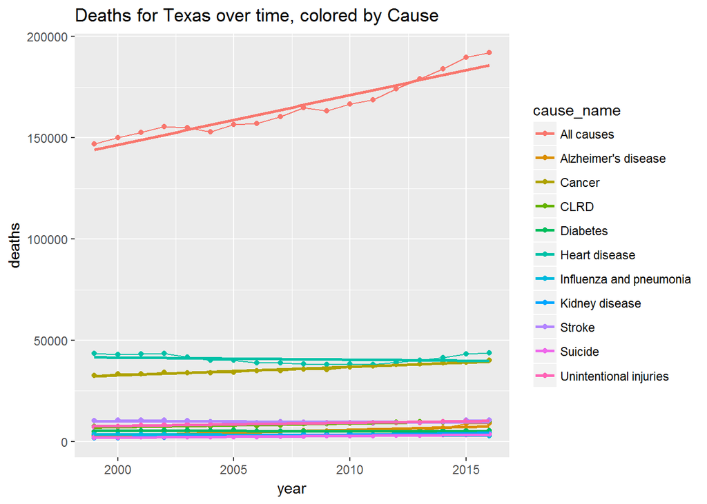

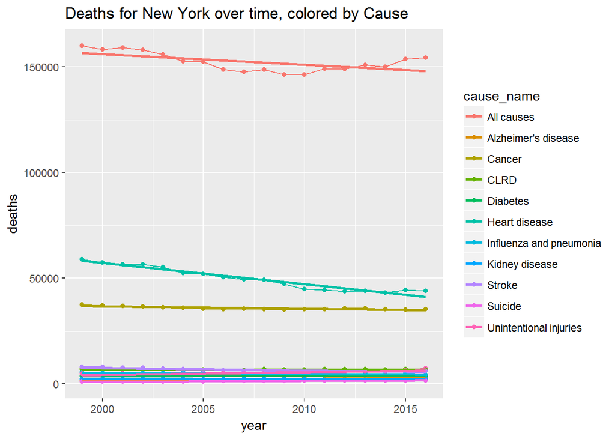

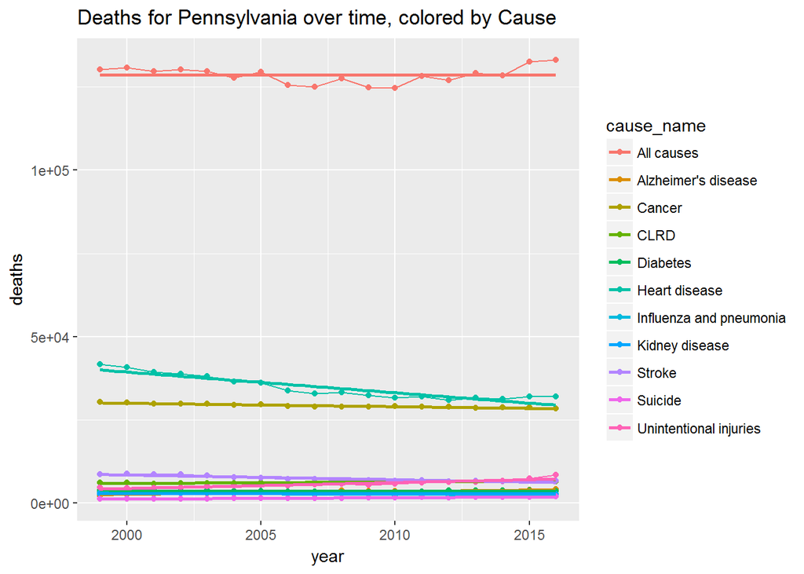

```r
# Plot the 5 states with most overall deaths, using the map() function (purrr)
map(top_states_deaths, plot_state_deaths)
```

# Analysis

## Leading causes of death in 2016

What were the 2 leading aadr causes of death for each region in 2016?

```r
lcod_reg %>%
  # Filter such that only data for the year 2016 is selected, and filter out 'All causes' of death
  filter(year == 2016, cause_name != "All causes") %>%
  # Group the data by a combination of region and causes
  group_by(region, cause_name) %>%
  # Create summaries of the mean adjusted death rate, by causes of death per region
  summarize(mean_aadr = mean(age_adjusted_death_rate)) %>%
  # Select the top 2 causes of death per region
  top_n(2) %>%
  # Sort result in descing order
  arrange(desc(mean_aadr))
```

```
## # A tibble: 10 x 3
## # Groups: region [5]
##    region        cause_name    mean_aadr
##    <fctr>        <fctr>            <dbl>
##  1 South         Heart disease       190
##  2 South         Cancer              169
##  3 United States Heart disease       166
##  4 Midwest       Heart disease       163
##  5 Midwest       Cancer              160
##  6 Northeast     Heart disease       157
##  7 Northeast     Cancer              156
##  8 United States Cancer              156
##  9 West          Heart disease       148
## 10 West          Cancer              143
```

## Comparison of cause of death between 1999 and 2016

Firstly, the following code summarizes mean aadr by region and cause for 1999 and 2016

```r
lcod_reg_99_16 <- lcod_reg %>%
  # Filter out any year that isn't 1999 or 2016
  filter(year == 1999 | year == 2016) %>%
  # Group by a combination of region, year and cause of death
  group_by(region, year, cause_name) %>%
  # Create summaries of mean adjusted death rate by region, year, and cause of death
  summarize(mean_aadr = mean(age_adjusted_death_rate))
```

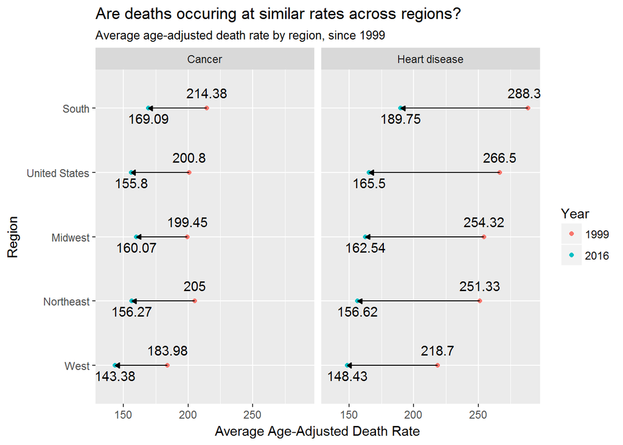

```r
lcod_reg_99_16 %>%
  # Filter out rows that do not include Cancer or Heart Disease as the cause of death
  filter(cause_name %in% c("Cancer", "Heart disease")) %>%
  # Create an arrow plot to show the trend between the two years
  ggplot(aes(x = mean_aadr, y = fct_reorder(region, mean_aadr))) +
    # Add a scatterplot layer, colored by year
    geom_point(aes(color = as.factor(year))) +
    # Add the arrow layer to the plot
    geom_path(arrow = arrow(length = unit(1.5, "mm"), type = "closed")) +
    # Add faceting, so that Cancer and Heart Disease are plotted side by side
    facet_wrap(~ cause_name) +
    # Make adjustments to the numeric values displayed above/below the points, for improved readability
    geom_text(aes(x = mean_aadr, y = region, label = round(mean_aadr, 2),
                vjust = ifelse(year == "2016", 1.5, -1.0))) +
    # Add proper descriptive labels to the plot
    labs(x = "Average Age-Adjusted Death Rate", y = "Region",
       title = "Are deaths occuring at similar rates across regions?",
       subtitle = paste("Average age-adjusted death rate by region, since 1999")) +
    # Add label to color legend
    scale_color_discrete(name = "Year") +
    # Zoom in the plot by adjusting viewing area on the x-axis
    coord_cartesian(xlim = c(136, 290))
```

The next faceted plot shows the trend in Alzheimer’s Disease and CLRD between 1999 and 2016. In this case, it can be seen that Alzheimer’s disease is one of the few major causes of death that has actually increased substantially in all regions during this time frame. For CLRD, there is a modest decrease in the West and Northeast, with little change elsewhere.

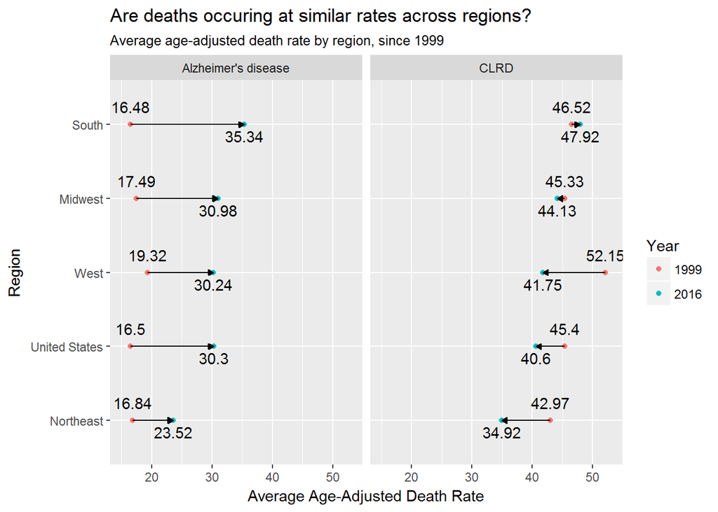

```r
lcod_reg_99_16 %>%
  # Filter out rows that do not include Alzheimer's disease or CLRD as the cause of death
  filter(cause_name %in% c("Alzheimer's disease", "CLRD")) %>%
  # Create an arrow plot to show the trend between the two years
  ggplot(aes(x = mean_aadr, y = fct_reorder(region, mean_aadr))) +
    # Add a scatterplot layer, colored by year
    geom_point(aes(color = as.factor(year))) +
    # Add the arrow layer to the plot
    geom_path(arrow = arrow(length = unit(1.5, "mm"), type = "closed")) +
    # Add faceting, so that Alzheimer's disease and CLRD are plotted side by side
    facet_wrap(~ cause_name) +
    # Make adjustments to the numeric values displayed above/below the points, for improved readability
    geom_text(aes(x = mean_aadr, y = region, label = round(mean_aadr, 2),
                vjust = ifelse(year == "2016", 1.5, -1.0))) +
    # Add proper descriptive labels to the plot
    labs(x = "Average Age-Adjusted Death Rate", y = "Region",
       title = "Are deaths occuring at similar rates across regions?",
       subtitle = paste("Average age-adjusted death rate by region, since 1999")) +
    # Add label to color legend
    scale_color_discrete(name = "Year") +
    # Zoom in the plot by adjusting viewing area on the x-axis
    coord_cartesian(xlim = c(15, 53))
```

## Transform dataset to uncover correlations

To get a better understanding of possible correlations within causes of death, the dataset can be restructured so that each cause of death is a variable, rather than a sub-category.

```r
# Transform dataset from long to wide: age_adjusted_death_rate
lcod_reg_wide <- select(lcod_reg, -deaths) %>%
  # The spread function (dplyr) takes a categorical variable and splits it into numerous keys,
  # with values supplied by the value column argument
  spread(key = cause_name, value = age_adjusted_death_rate)
```

Below is a snapshot of the first 10 rows in the restructured dataset.

```r
# View first 10 rows of restructured data
head(lcod_reg_wide, 10)
```

```
## # A tibble: 10 x 14
##     year state regi~ `All~ `Alz~ Canc~  CLRD Diab~ `Hea~ `Inf~ `Kid~ Stro~
##    <int> <fct> <fct> <dbl> <dbl> <dbl> <dbl> <dbl> <dbl> <dbl> <dbl> <dbl>
##  1  1999 Alab~ South  1009 17.8    211  48.6  30.0   303  28.2 22.2   71.5
##  2  1999 Alas~ West    839 11.9    190  56.4  23.8   198  19.6 13.4   71.2
##  3  1999 Ariz~ West    818 20.8    180  51.2  21.5   223  27.2 11.1   54.4
##  4  1999 Arka~ South   975 14.8    214  46.8  24.2   288  25.5 15.9   77.7
##  5  1999 Cali~ West    802 16.6    185  46.9  22.5   257  16.5  8.00  64.5
##  6  1999 Colo~ West    802 24.5    171  58.1  19.2   196  25.3  9.60  57.2
##  7  1999 Conn~ Nort~   783 11.4    191  37.8  18.5   239  22.7 12.1   50.0
##  8  1999 Dela~ South   882 15.0    223  42.7  23.5   269  21.3 13.4   49.4
##  9  1999 Dist~ South  1087  9.50   241  29.9  39.6   296  20.6 16.4   53.3
## 10  1999 Flor~ South   813 14.3    191  43.1  21.5   248  16.1  8.90  50.5
## # ... with 2 more variables: Suicide <dbl>, `Unintentional injuries` <dbl>
```

### Correlation plot

Now that the data has been restructured, correlations between the causes of death can be computed and plotted.

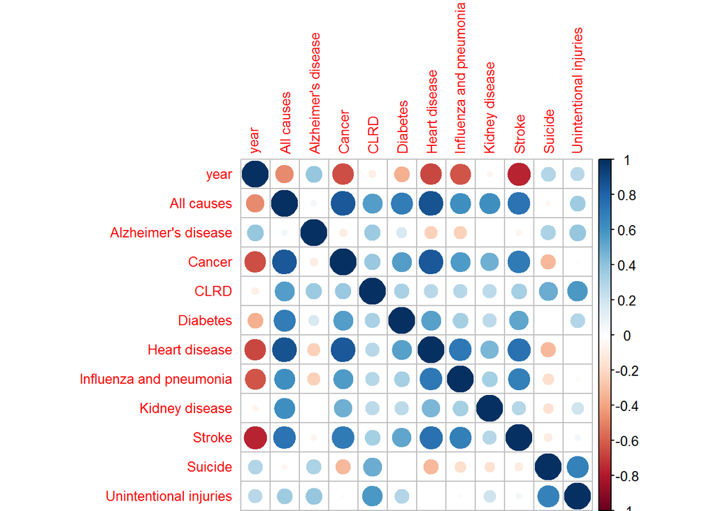

```r
# Create correlation matrix and then plot correlations for year, causes of death
# First, deselect categorical variables 'state' and 'region'
select(lcod_reg_wide, -state, -region) %>%
  # Create the correlation matrix
  cor() %>%
  # Create the correlation plot
  corrplot(tl.cex = .8)
```

### Line plot of all states for all causes of death

Although this faceted plot is very noisy due to the number of states included, because the states are ordered by higher ‘all causes’ death rates, there is a clear trend: the first 11 states (those with highest *all cause* age-adjusted death rates) are all from the South region.

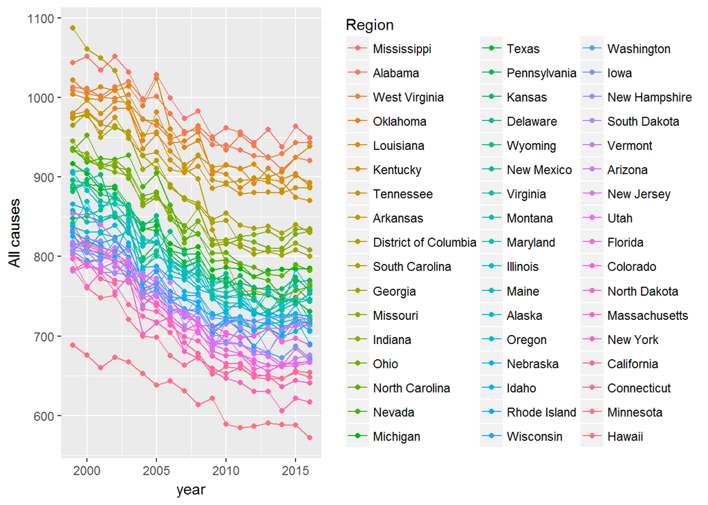

```r
# Create line/point plot of all states, all causes of death
lcod_reg_wide %>%
  # Filter out the rows that include the United States at large
  filter(state != "United States") %>%
  # Create ggplot and aesthetic mappings, notably reordering the 'state' variable according to 'all causes'
  ggplot(aes(x = year, y = `All causes`, color = fct_rev(fct_reorder(state, `All causes`)))) +
  # Add scatterplot layer to the plot
  geom_point() +
  # Add line layer to the plot
  geom_line() +
  # Add label to color legend
  scale_color_discrete(name = "Region")
```

### Subset of states for all causes of death

To get a closer look, let’s examine the same plot but with only the 2 highest states, the 2 lowest, and an interesting case that dips dramatically from 1999 to 2016. Hawaii has a considerably lower rate than even the 2nd lowest state, Minnesota.

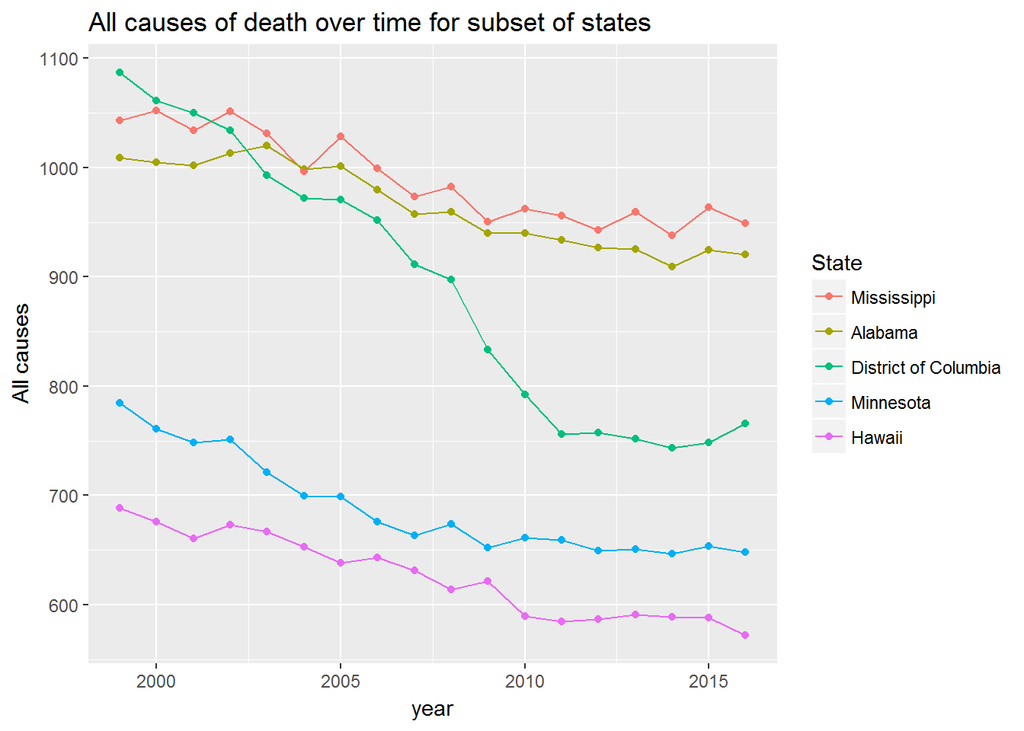

```r
# Recrease the line/point plot with a subset of states for all causes: 2 highest, 2 lowest, + Dc
lcod_reg_wide %>%
  # Filter out any undesired states, those not in this list
  filter(state %in% c("Mississippi", "Alabama", "District of Columbia", "Minnesota", "Hawaii")) %>%
  # Create ggplot and aesthetic mappings, notably reordering the 'state' variable according to 'all causes'
  ggplot(aes(x = year, y = `All causes`, color = fct_rev(fct_reorder(state, `All causes`)))) +
  # Add scatterplot layer to the plot
  geom_point() +
  # Add line layer to the plot
  geom_line() +
  # Add a title to the plot
  labs(title = "All causes of death over time for subset of states") +
  # Add label to color legend
  scale_color_discrete(name = "State")
```

## District of Columbia

The District of Columbia had a drastic change in age adjusted death rates over the time period from 1999-2016. Next, let’s examine if there may be a similar trend within the various cause sub-categories.

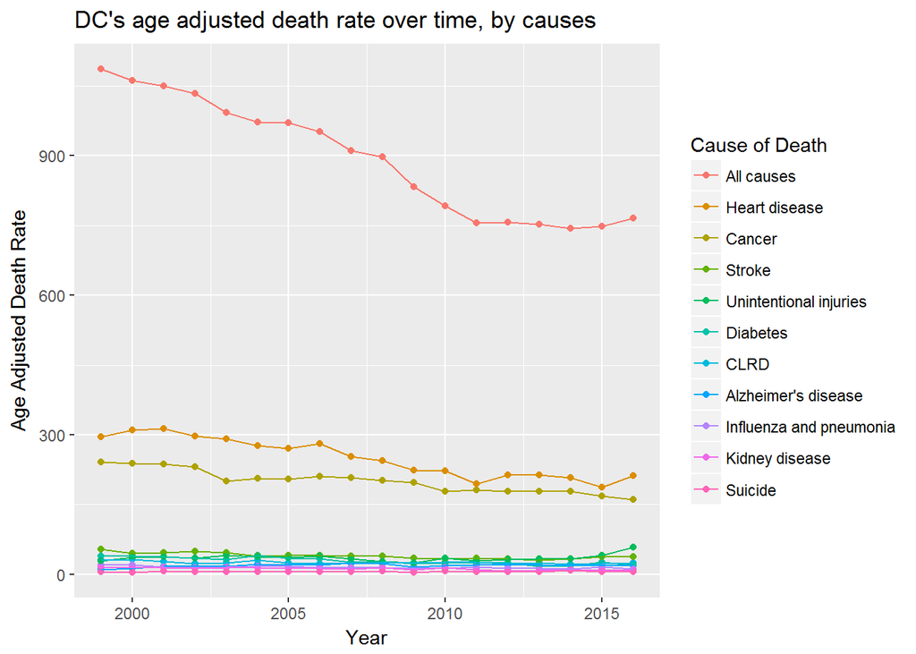

```r
# Investigate DC's causes of death in more detail
lcod_reg %>%
  # Filter out any rows that don't include DC
  filter(state == "District of Columbia") %>%
  # Create ggplot and aesthetic mappings and reorder causes by the age-adjusted death rate
  ggplot(aes(x = year, y = age_adjusted_death_rate, color = fct_rev(fct_reorder(cause_name, age_adjusted_death_rate)))) +
  # Add scatterplot layer to the plot
  geom_point() +
  # Add line layer to the plot
  geom_line() +
  # Add label to color legend
  scale_color_discrete(name = "Cause of Death") +
  # Add title and change x, y axis labels
  labs(title = "DC's age adjusted death rate over time, by causes", y = "Age Adjusted Death Rate", x = "Year")
```

### Further analysis of DC’s causes of death

At first glance, the visual drop in *all causes* does not seem to be completely accounted for by the subcategories. We can compute a summary of the sub-categories of causes to determine what proportion of *all causes* they account for.

```r
# Create new dataframe: dc_addr containing DC's causes of death in 1999 vs 2016
dc_aadr <- lcod_reg %>%
  # Filter out any 'state' that isn't DC
  filter(state == "District of Columbia") %>%
  # Filter out 'All causes'
  filter(cause_name != "All causes") %>%
  # Group the data by year (1999 and 2016)
  group_by(year) %>%
  # Create sums of the age-adjusted death rate
  summarize(sum_aadr = sum(age_adjusted_death_rate))

# Add age-adjusted death rate from DC's 'All causes'
dc_aadr$all_causes <- lcod_reg %>%
  # Filter out rows with any 'state' that isn't DC
  filter(state == "District of Columbia") %>%
  # Filter out rows with any cause that isn't 'All causes'
  filter(cause_name == "All causes") %>%
  # Select only the age_adjusted_death_rate column
  select(age_adjusted_death_rate) %>%
  # Retrieve the vector (column), to be stored in dc_aadr$all_causes
  pull()
```

The code below computes the proportion of the 10 causes in this data set over *all causes* reveals an interesting anomaly in the 2016 data.

```r
# Calculate proportion of causes included within all_causes
dc_aadr <- dc_aadr %>%
  # Using mutate, create a new column, prop, the proportion of the combined causes' aadr over 'all causes'
  mutate(prop = sum_aadr/all_causes)
```

It appears that there are other causes for the death rate in the District of Columbia, particularly in recent years, which are not captured by this dataset. Since 2002, there has been a downward trend in the proportion of *all causes* that are accounted for by sub-categories.

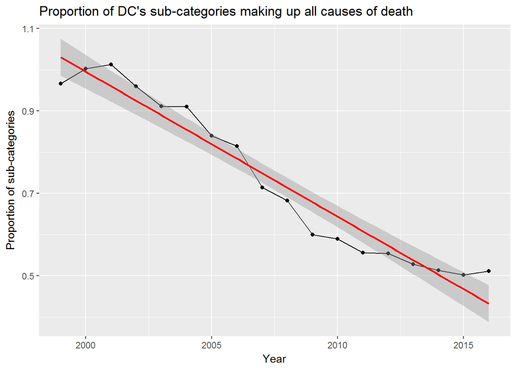

```r
# Create ggplot and aesthetic mappings
ggplot(dc_aadr, aes(x = year, y = prop)) +
  # Add scatterplot layer to the plot
  geom_point() +
  # Add line layer to the plot
  geom_line() +
  # Add smoothing with linear model
  geom_smooth(method = "lm", color = "red") +
  # Add title and adjust axis labels
  labs(title = "Proportion of DC's sub-categories making up all causes of death",
       y = "Proportion of sub-categories", x = "Year")
```